신록예찬's 블로그

# (노트) matplotlib + seaborn, qqplot

Sep 25, 2021 • 신록예찬 • 6 min read

시각화

- import
- matplotlib + seaborn
  - matplotlib vs seaborn
- 예제: 정규분포를 판단하기 위해서는? 히스토그램??
- qqplot의 아이디어

### import

```python
import numpy as np
import matplotlib.pyplot as plt
from scipy import stats
```

### matplotlib + seaborn

`-` 키+뭄무게 예제를 조금 바꿔보자.

```python
x=[44,48,49,58,62,68,69,70,76,79] ## 몸무게
y=[159,160,162,165,167,162,165,175,165,172] ## 키
g= 'f','f','f','f','m','f','m','m','m','m'
```

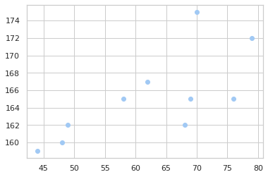

```python
plt.plot(x,y,'o')
```

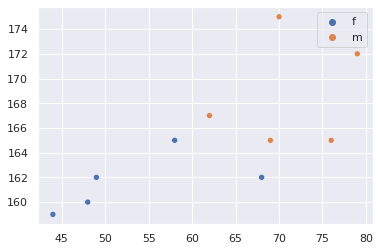

```python
sns.scatterplot(x=x,y=y,hue=g)
```

`-` 머 어쩌라는것이지?..

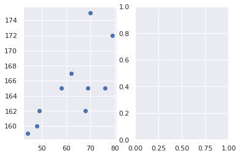

```python
fig, (ax1,ax2) = plt.subplots(1,2)
ax1.plot(x,y,'o')
```

```python
sns.scatterplot(x=x,y=y,hue=g,ax=ax2)
```

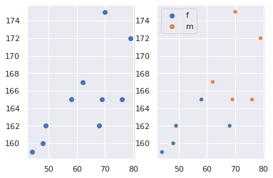

```python
fig
```

```python
fig.set_figwidth(8)
```

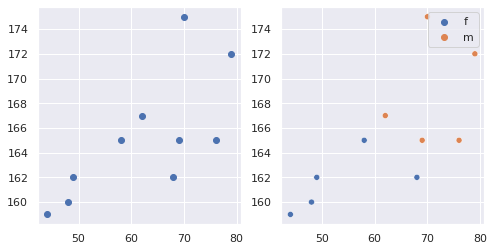

```python
fig
```

```python
ax1.set_title('matplotlib')
ax2.set_title('seaborn')
```

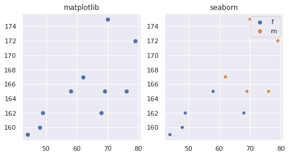

```python
fig
```

`-` 좀 더 자세한 내용은 seaborn 공식홈페이지를 참고하라.

#### matplotlib vs seaborn

`-` 보통 아래와 같이 생각하는 학생들이 있다.

- 파이썬의 시각화 패키지는 다양하다 (matplotlib, seaborn, plotnine, plotly ...)
- 이것저것 공부하지말고 한가지를 선택하여 장인이 되자..
- 적당하게 비교해보니까 디자인이 seaborn이 예쁜것 같으므로 나는 seaborn을 배우겠다.

`-` 괜찮은 전략인것 같으나 사실 비효율적이다. matplotlib은 어머니, seaborn은 자식과 같은 존재인데 matplotlib을 이해하지 못하는 상태에서 seaborn을 익히는것은 무리가 있다.

`-` 특히 위험한 생각중 하나는 "디자인이 예쁜것 같으니까" 이다. (테마는 입히면 된다..)

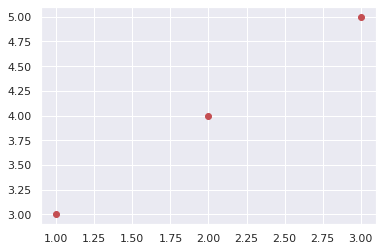

```python
sns.set_theme()
plt.plot([1,2,3],[3,4,5],'or')
```

### 예제: 정규분포를 판단하기 위해서는? 히스토그램??

`-` 전북고예제: 통계학에서 제시하는 통계량(평균)이 의미가 있으려면 적절한 분포가 가정되어야 한다.

`-` 분포의 가정되었는지 어떻게 알지? 히스토그램?

`-` 아래와 같은 자료가 있다고 하자.

```python
np.random.seed(43052)
x=np.random.normal(size=1000,loc=2,scale=1.5)
```

`-` 이 자료가 정규분포를 따르는지 어떻게 체크할 수 있을까?

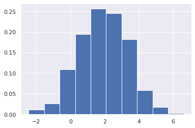

```python
plt.hist(x,density=True)
```

`-` 종모양이다..?

`-` 밀도추정곡선이 있었으면 좋겠다. (KDE로 추정한..)

- 그런데 KDE는 통계적 기법이 포함된 시각화이므로 기본적인 패키지인 matplotlib에서는 지원불가능
- seaborn에는 구현되어있음

`-` seaborn으로 그려보자.

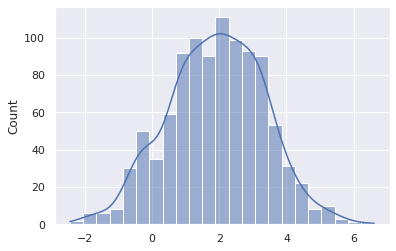

```python
sns.histplot(x,kde=True)
```

`-` 종모양 같다.

`-` 그렇다면 아래는 어떤가?

```python
np.random.seed(43052)
y = stats.t.rvs(10, size=1000)
```

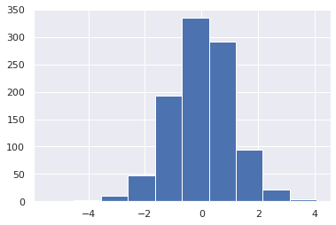

```python
plt.hist(y)
```

`-` 종 모양이다..?

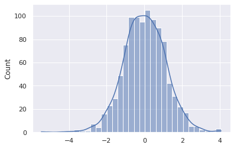

```python
sns.histplot(y,kde=True)
```

`-` 비교

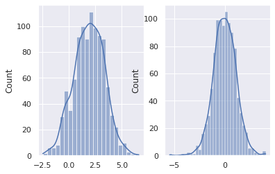

```python
fig, (ax1,ax2)=plt.subplots(1,2)
sns.histplot(x,kde=True,ax=ax1)
sns.histplot(y,kde=True,ax=ax2)
```

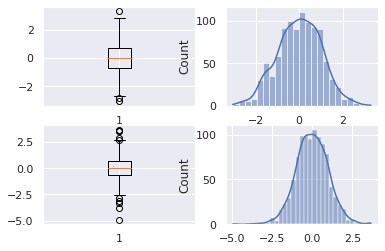

```python
xx= (x-np.mean(x))/np.std(x,ddof=1)
yy= (y-np.mean(y))/np.std(y,ddof=1)

fig, ((ax1,ax2),(ax3,ax4)) =plt.subplots(2,2)
ax1.boxplot(xx)
sns.histplot(xx,kde=True,ax=ax2)
ax3.boxplot(yy)
sns.histplot(yy,kde=True,ax=ax4)
```

```python
fig.tight_layout()
```

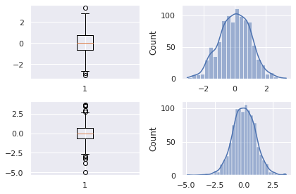

```python
fig
```

`-` 좀 이상하다..

- 일단 이 분포는 정규분포가 아니었음. $\to$ "히스토그램을 그려보니 모양이 종모양이므로 정규분포라고 볼수있다" 라고 결론내리면 오류임
- 자세히보니까 모양이 약간 다른것 같기도하고... (꼬리가 두꺼움)

`-` 종모양의 히스토그램으로 정규분포인지 판단하는것은 무리가 있어보인다. $\to$ 좀 더 체계적인 방법이 필요함.

### qqplot의 아이디어

`-` 우리가 관측한 $x_1,\dots, x_{1000}$이 $N(2,1.5^2)$에서 나온 샘플인지 궁금하다.

- 실제로는 생성했지만 관측했다고 하자, 그러니가 교수가 csv파일에 담아서 줬다고 가정하자

`-` 아래와 같이 비교하면 좋을것 같다.

(1) 관측한 값을 순서대로 나열하여 $x_{(1)},\dots,x_{(1000)}$을 만든다.

(2) 파이썬이나 R을 통해서 $N(2,1.5^2)$에서 1000개의 정규분포를 생성한다. 그리고 순서대로 나열하여 $y_{(1)},\dots,y_{(1000)}$을 만든다.

(3) $x_{(1)}\approx y_{(1)}, \dots , x_{(1000)}\approx y_{(1000)}$이면 정규분포일것

`-` 그런데 $y_{(1)},\dots, y_{(1000)}$은 시뮬레이션 할때마다 다른값이 나올테니까 불안정한 느낌이다. $\to$ 이론적으로 $y_{(1)}, \dots, y_{(1000)}$을 계산하자.

```python
x[:20]
```

[output not shown]

```python
x.sort()
```

```python
x[:20] ## 순서대로 정렬
```

```
array([-2.44398446, -2.14071467, -1.91699446, -1.90807041, -1.85258125,
       -1.82756518, -1.73287737, -1.69803322, -1.57630195, -1.55481746,
       -1.50382925, -1.50121434, -1.33115464, -1.29462794, -1.17506839,
       -1.10932362, -1.09436262, -1.04511377, -1.01881274, -1.00534334])
```

`-` 우선 x에서 평균을 빼고 표준편차를 나누어 xx를 만들자.

```python
xx = (x-np.mean(x)) / np.std(x,ddof=1)
```

```python
xx[:20]
```

```
array([-3.05569305, -2.84275629, -2.68567418, -2.67940829, -2.64044732,
       -2.62288263, -2.55639887, -2.53193353, -2.44646157, -2.43137652,
       -2.39557585, -2.39373982, -2.27433471, -2.24868799, -2.16474088,
       -2.11857908, -2.10807442, -2.073495  , -2.0550281 , -2.04557074])
```

`-` 이론적인 분위수를 계산

`xx[0]`은 대략 주어진 자료의 $\frac{1}{1000}$분위수라고 볼 수 있다.

표준정규분포표를 이용하여 찾아보면

```python
stats.norm.ppf(0.01)
stats.norm.ppf(0.02)
```

```
-2.053748910631823
```

`-` 분위수

```python
m=[i/n for i in np.arange(1000)+1]
```

```
### 보정하는방법1
n=len(xx)
m=[((i+1)-0.3175)/(n+0.365) for i in range(n)]
m[-n]=0.5**(1/n)
m[0]=1-m[-n]
### 보정하는방법2
m=[(i-3/8)/(n+1/4) for i in np.arange(100)+1]
```

`-` 방법1

```python
q=[]
for i in range(len(m)):
    q=q+[stats.norm.ppf(m[i])]
q[:20]
```

```
[-3.090232306167813,
 -2.878161739095483,
 -2.7477813854449926,
 -2.6520698079021954,
 -2.575829303548901,
 -2.5121443279304616,
 -2.457263390205437,
 -2.408915545815461,
 -2.3656181268642924,
 -2.3263478740408408,
 -2.2903678778552674,
 -2.2571292444862254,
 -2.226211769317175,
 -2.197286376641052,
 -2.1700903775845606,
 -2.1444106209118403,
 -2.120071689742151,
 -2.0969274291643423,
 -2.07485473439331,
 -2.053748910631823]
```

`-` 방법2

```python
q=[stats.norm.ppf(m[i]) for i in range(len(q))]
q[:20]
```

```
[-3.090232306167813,
 -2.878161739095483,
 -2.7477813854449926,
 -2.6520698079021954,
 -2.575829303548901,
 -2.5121443279304616,
 -2.457263390205437,
 -2.408915545815461,
 -2.3656181268642924,
 -2.3263478740408408,
 -2.2903678778552674,
 -2.2571292444862254,
 -2.226211769317175,
 -2.197286376641052,
 -2.1700903775845606,
 -2.1444106209118403,
 -2.120071689742151,
 -2.0969274291643423,
 -2.07485473439331,
 -2.053748910631823]
```

`-` 방법3

```python
q=list(map(stats.norm.ppf,m))
q[:20]
```

```
[-3.090232306167813,
 -2.878161739095483,
 -2.7477813854449926,
 -2.6520698079021954,
 -2.575829303548901,
 -2.5121443279304616,
 -2.457263390205437,
 -2.408915545815461,
 -2.3656181268642924,
 -2.3263478740408408,
 -2.2903678778552674,
 -2.2571292444862254,
 -2.226211769317175,
 -2.197286376641052,
 -2.1700903775845606,
 -2.1444106209118403,
 -2.120071689742151,
 -2.0969274291643423,
 -2.07485473439331,
 -2.053748910631823]
```

`-` 방법4

```python
q=stats.norm.ppf(m)
q[:20]
```

```
array([-3.09023231, -2.87816174, -2.74778139, -2.65206981, -2.5758293 ,
       -2.51214433, -2.45726339, -2.40891555, -2.36561813, -2.32634787,
       -2.29036788, -2.25712924, -2.22621177, -2.19728638, -2.17009038,
       -2.14441062, -2.12007169, -2.09692743, -2.07485473, -2.05374891])
```

`-` matploblib

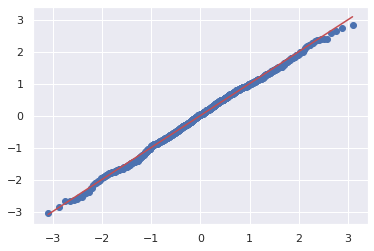

```python
plt.plot(q,xx,'ob')
plt.plot(q,q,'-r')
```

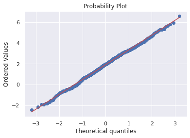

```python
from scipy import stats
_ = stats.probplot(x,plot=plt)
```

`-` t분포는?

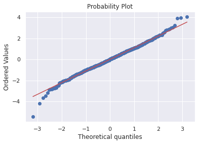

```python
_ = stats.probplot(y,plot=plt)
```

`-` 확실하게 달라보인다.

`-` 서브플랏팅

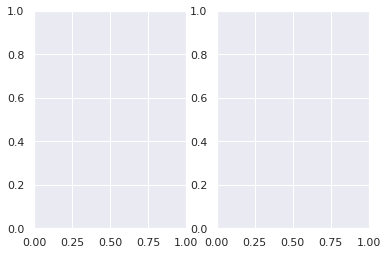

```python
fig,(ax1,ax2) =plt.subplots(1,2)
```

```python
from scipy import stats
_ = stats.probplot(x,plot=ax2)
```

```python
fig.tight_layout()
```

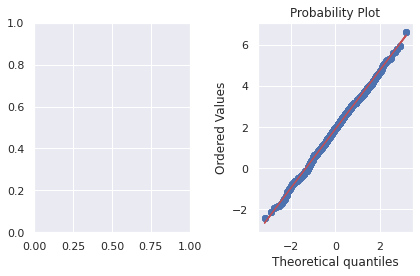

```python
fig
```

```python
import rpy2
%load_ext rpy2.ipython
```

```python
%R -i xx
```

```python
%R -o rq,rxx
```

```python
rxx,xx
```

[output not shown]

```python
rq,q
```

[output not shown]